# Tema 2.3 - Análisis Exploratorio de los Datos

Roi Naveiro

2022-12-18

# Análisis Exploratioro de los Datos

- Aprenderemos cómo explorar los datos de forma sistemática…
- …usando las herramientas aprendidas (visualización y transformación)
- El Análisis Exploratior de los datos es un ciclo que consiste en
  1. Generar preguntas sobre los datos
  2. Responderlas visualizanddo, transformando y modelizando
  3. Usar lo aprendido para refinar preguntas o crear nuevas cuestiones

# Análisis Exploratioro de los Datos

- **Objetivo**: desarrollar entendimiento acerca de los datos
- Útil hacerlo a través de preguntas
  - Permiten centrarnos en una parte de los datos
  - Perimten decidir qué gráficos, modelos y transformaciones utilizar
- Proceso **creativo**

# Análisis Exploratioro de los Datos

- Proceso **creativo**: no hay reglas para determinar qué preguntas son las más útiles.
- Dos tipos de preguntas (casi siempre) interesantes:
  - ¿Qué tipo de variación está presente en mis variables?
  - ¿Qué tipo de co-variación aparece **entre** mis variables?

# Un poco de jerga

- **Variable**: propiedad que puede ser medida
- **Valor**: estado de la variable cuando se mide. ¡Puede cambiar si se repite la medida!
- **Observación**: conjunto de medidas tomadas en condiciones similares (e.g. sobre un mismo sujeto). Varios valores, cada uno asociado a diferentes variables
- **Datos Tabulares**: conjunto de valores, cada uno asociado a una variable y una observación. Variables en columnas, observaciones en filas.

# EDA: Variación

# Variación

*Variación es la tendencia de los valores de una variable a cambiar de medida a medida*

Esta variación puede estar asociada a distintos fenómenos:

- **Error de medición** al medir una cantidad constante (velocidad de la luz)
- Medición de misma variable en **diferentes sujetos**
- Medición de una misma variable, en el mismo sujeto, en **tiempos diferentes**
- …

El patrón de variación da información interesante…

… que se destila visualizado la **distribución de valores de la variable**

# Variación: variable categórica

Recordemos cómo visualizar la distribución de una **variable categórica**

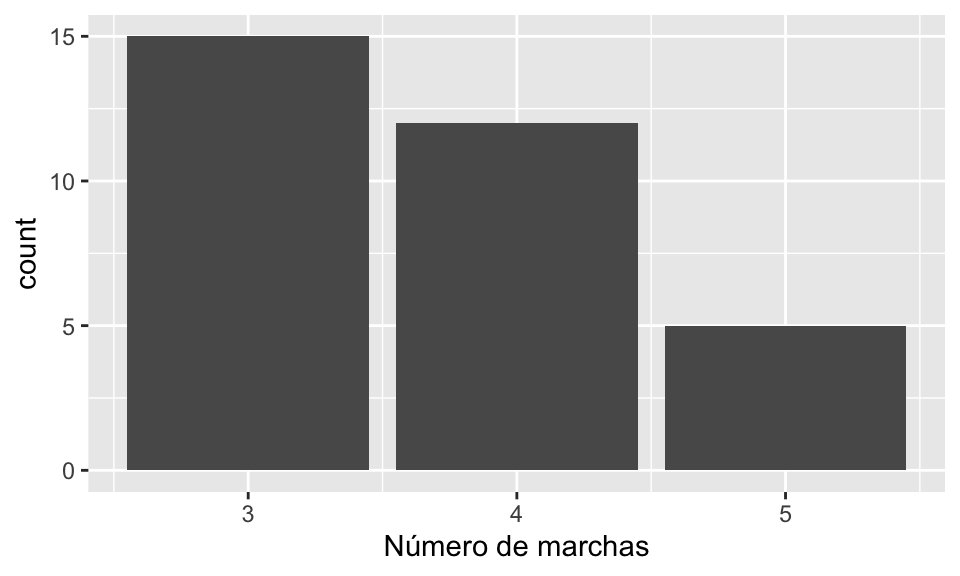

```r
library(ggplot2)
# Representamos número de marchas en datos mtcars
ggplot(data=mtcars, aes(x=gear)) +
  geom_bar() +
  labs(x = "Número de marchas")
```

# Variación: variable categórica

La altura de las barras muestran el número de observaciones. ¿Cómo obtendrías este número?

–

```r
library(tidyverse)
mtcars %>% group_by(gear)  %>% summarise(n())
```

```
## # A tibble: 3 × 2
##    gear `n()`
##   <dbl> <int>
## 1     3    15
## 2     4    12
## 3     5     5
```

# Variación: variable contínua

También habíamos visto cómo visualizar la distribución de variables contínuas

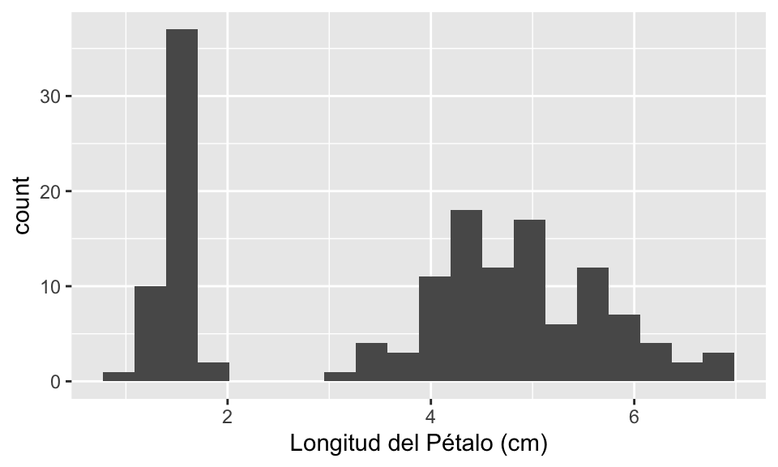

```r
ggplot(data=iris, aes(x=Petal.Length)) +
  geom_histogram(bins = 20) +
  labs(x = "Longitud del Pétalo (cm)")
```

# Variación

¿Qué debemos buscar en gráficos de variación? ¿Qué preguntas hacer?

- Valores típicos
- Valores atípicos

# Variación: valores típicos

- ¿Qué valores son los más comunes?
- ¿Cuáles los menos comunes?
- ¿Existe algún patrón inusual?

# Ejemplo: longitud de pétalo

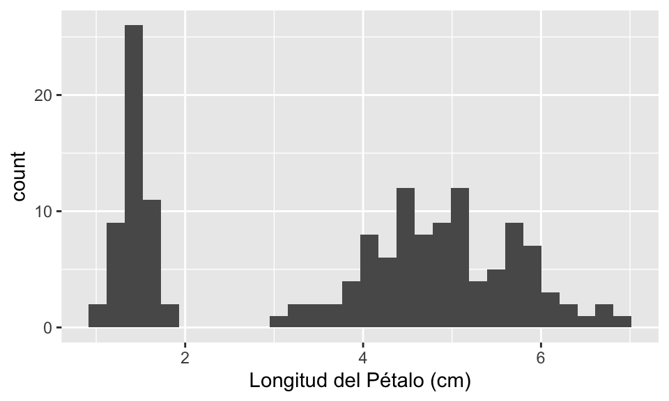

```r
ggplot(data=iris, aes(x=Petal.Length)) +
  geom_histogram() +
  labs(x = "Longitud del Pétalo (cm)")
```

# Ejemplo: longitud de pétalo

Los *clusters* de valores similares sugieren que existen subgrupos en los datos. Para entenderlos, conviene que preguntarse

- ¿Qué tienen en común las observaciones de cada subgrupo?
- ¿Qué diferencia a las observaciones de distintos subgrupos?
- ¿Cómo podemos explicar los subgrupos?

–

- Existe un grupo de flores con pétalos cortos (<2cm) y otro con pétalos largos (>2cm)
- ¿Explica la variable especia esta separación?

# Variación: variable contínua

- Si se quieren visualizar varios histogramas en la misma gráfica, se pueden usar colores
- A veces más claro usar `geom_freqpoly()`
- Igual que histograma, pero pintado con lineas poligonales

# Variación: variable contínua

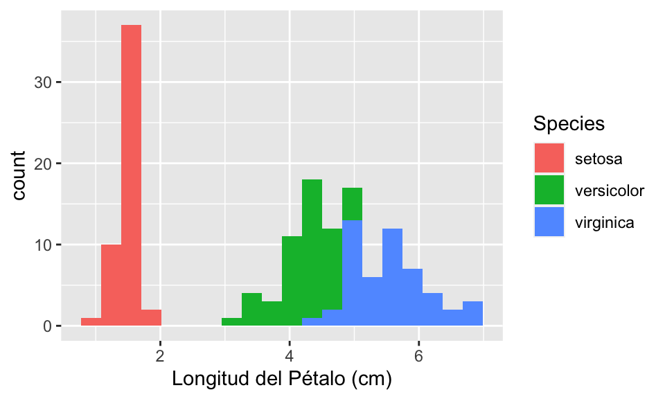

```r
ggplot(data=iris, aes(x=Petal.Length, fill=Species)) +
  geom_histogram(bins = 20) +
  labs(x = "Longitud del Pétalo (cm)")
```

# Variación: variable contínua

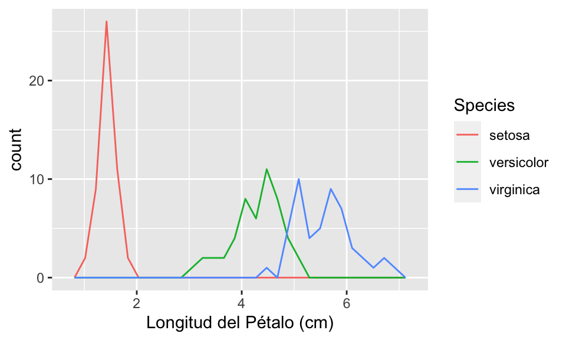

```r
ggplot(data=iris, aes(x=Petal.Length, color=Species)) +
  geom_freqpoly() +
  labs(x = "Longitud del Pétalo (cm)")
```

# Variación: valores atípicos

- Encontrar **valores atípicos** (outliers) Tan importante como estudiar los valores típicos
- Valores atípicos:
  - A veces, errores de medida
  - Otras, importantes descubrimientos!

# Ejemplo: anchura de los diamantes

Estudiemos la distribución de la anchura de los diamantes en el dataset `diamonds` (más información en `?diamonds`)

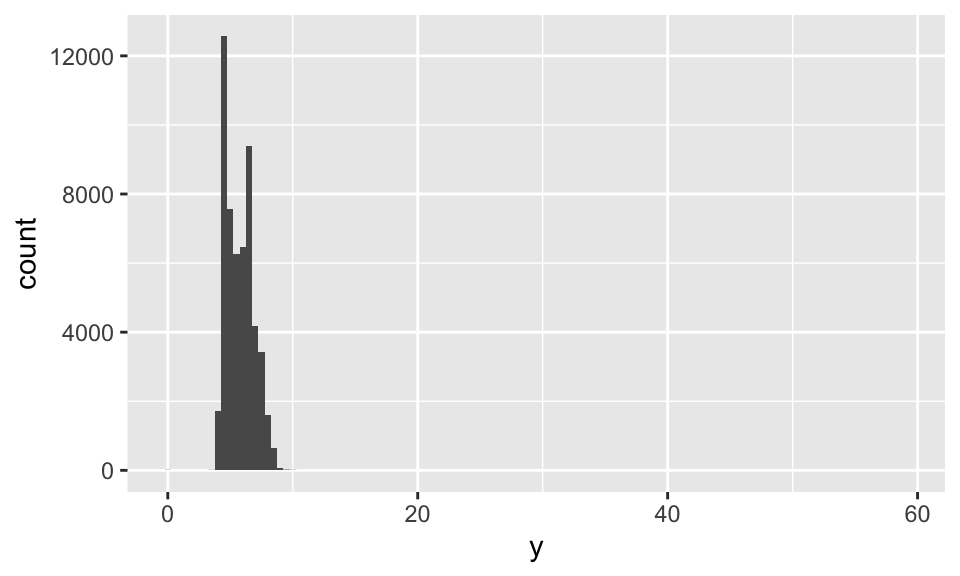

```r
ggplot(diamonds, aes(x=y)) +
  geom_histogram(binwidth = 0.5)
```

# Ejemplo: anchura de los diamantes

Aparentemente nada raro, pero…

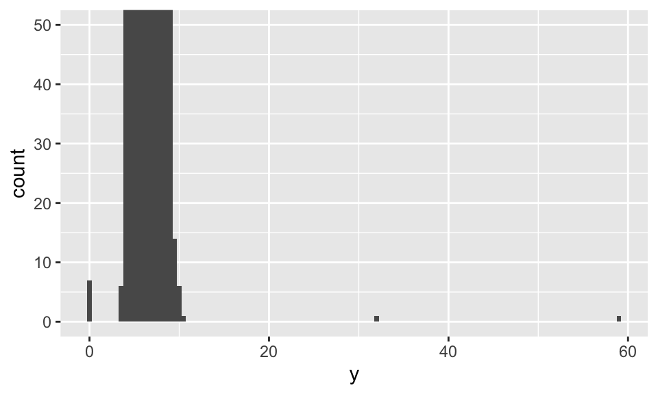

```r
ggplot(diamonds, aes(x=y)) +
  geom_histogram(binwidth = 0.5) +
  coord_cartesian( ylim = c(0,50) )
```

# Ejemplo: anchura de los diamantes

Parece ser que hay valores atípicos en torno al 0, 30 y 60.

# Vamos a extraerlos con `filter`

```r
diamonds %>%
  filter(y < 3 | y > 20)
```

```
## # A tibble: 9 × 10
##   carat cut       color clarity depth table price     x     y     z
##   <dbl> <ord>     <ord> <ord>   <dbl> <dbl> <int> <dbl> <dbl> <dbl>
## 1  1    Very Good H     VS2      63.3    53  5139  0      0    0
## 2  1.14 Fair      G     VS1      57.5    67  6381  0      0    0
## 3  2    Premium   H     SI2      58.9    57 12210  8.09  58.9  8.06
## 4  1.56 Ideal     G     VS2      62.2    54 12800  0      0    0
## 5  1.2  Premium   D     VVS1     62.1    59 15686  0      0    0
## 6  2.25 Premium   H     SI2      62.8    59 18034  0      0    0
## 7  0.51 Ideal     E     VS1      61.8    55  2075  5.15  31.8  5.12
## 8  0.71 Good      F     SI2      64.1    60  2130  0      0    0
## 9  0.71 Good      F     SI2      64.1    60  2130  0      0    0
```

# Ejemplo: anchura de los diamantes

- Parece que hay diamantes de medida 0. Datos incorrectos.
- Hay diamantes muy grandes, pero no demasiado caros…

# Variación: valores atípicos

- Suele ser útil repetir análisis con y sin outliers, para medir su efecto
- Si el efecto es mínimo y no sabemos su origen, reemplazar con `NA`
- Si no, solo quitarlos de manera **justificada** e informar de ello

# EDA: Valores ausentes

# Valores atípicos

Ante valores atípicos que se quieran eliminar, dos opciones:

- Eliminar fila entera (mucha pérdida de información)

```r
diamonds2 <- diamonds %>%
  filter(y>=3 & y<=20)
```

- Reemplazar valores atípicos con `NA`

```r
diamonds2 <- diamonds %>%
  mutate(y = ifelse(y<3 | y>20, NA, y))
```

- **NOTA**: primer argumento de `ifelse()` es lógico, segundo valor si `TRUE` y tercero, valor si `FALSE`

# Valores ausentes

Los valores ausentes se indican con un warning

```
## Warning: Removed 9 rows containing missing values (geom_point).
```

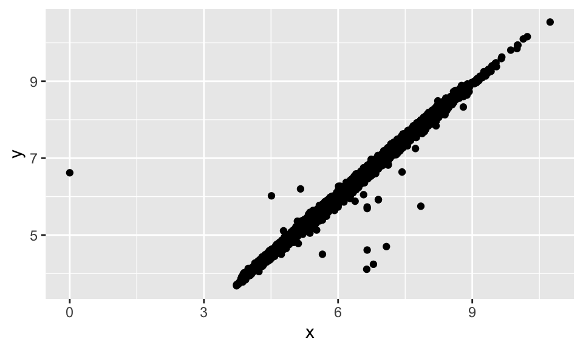

```r
ggplot(data=diamonds2, mapping = aes(x=x, y=y))+
  geom_point()
```

# Valores ausentes

Puede eliminarse con `na.rm = TRUE`

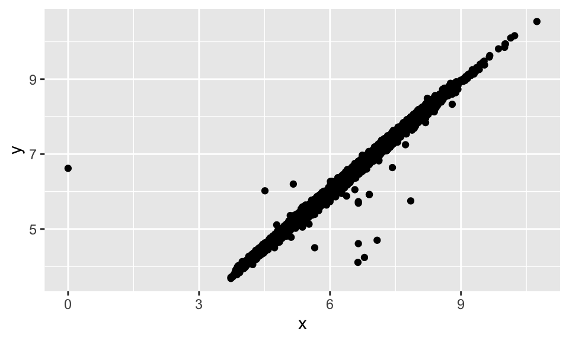

```r
ggplot(data=diamonds2, mapping = aes(x=x, y=y))+
  geom_point(na.rm = T)
```

# EDA: Covariación

# Covariación

- Tendencia de los valores de dos o más variables a cambiar conjuntamente
- La manera de visualizar covariación, depende del tipo de variables (como vimos)
  - Categórica - Contínua
  - Categórica - Categórica
  - Contínua - Contínua

# Covariación: Categórica - Contínua

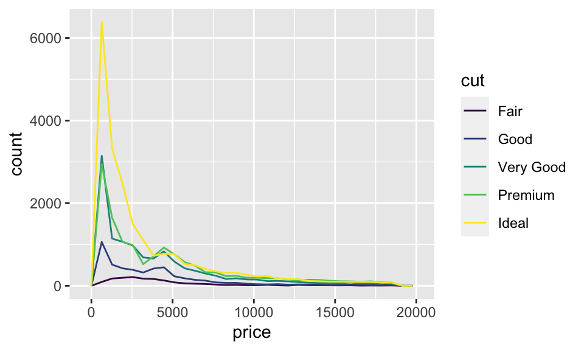

```r
ggplot(data=diamonds, aes(x=price, color=cut)) +
  geom_freqpoly()
```

# Covariación: Categórica - Contínua

`..density..` pinta densidad en eje y, que es la cuenta estandarizada para que el área de cada polígono sea 1

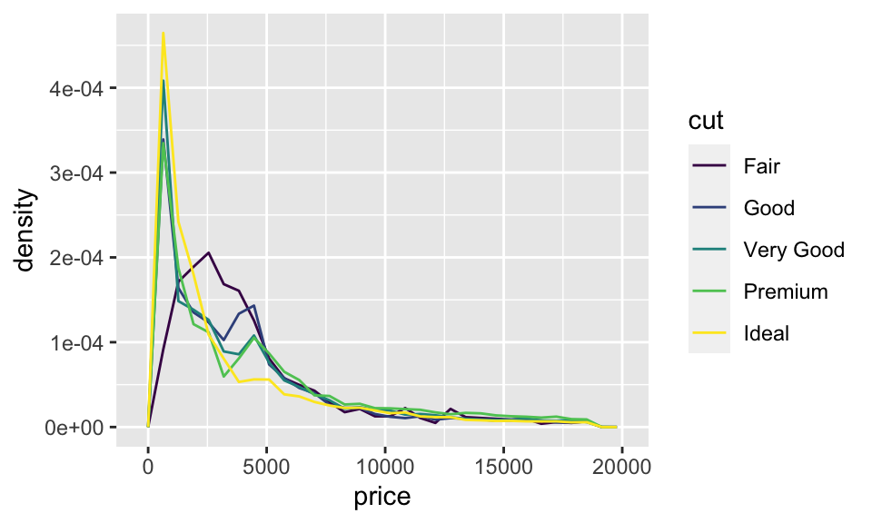

```r
ggplot(data=diamonds, aes(x=price, y=..density.., color=cut)) +
  geom_freqpoly()
```

# Covariación: Categórica - Contínua

# ¿Qué otra forma hay de visualizar covariación entre variables categóricas y contínuas?

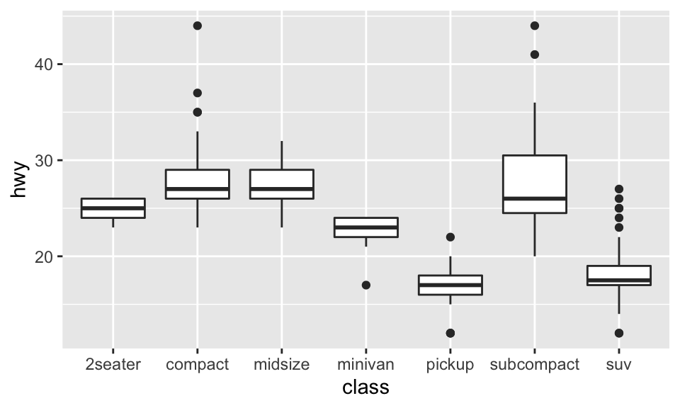

```r
ggplot(data = mpg, aes(x = class, y = hwy)) +
  geom_boxplot()
```

# Covariación: Categórica - Contínua

A veces, conviene reordenar…

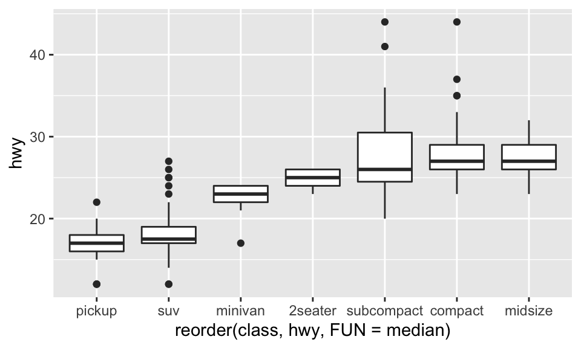

```r
ggplot(data = mpg, aes(x = reorder(class, hwy, FUN = median), y = hwy)) + #<<
  geom_boxplot()
```

# Covariación: Categórica - Categórica

Habíamos visto diagramas de barras. Otra forma:

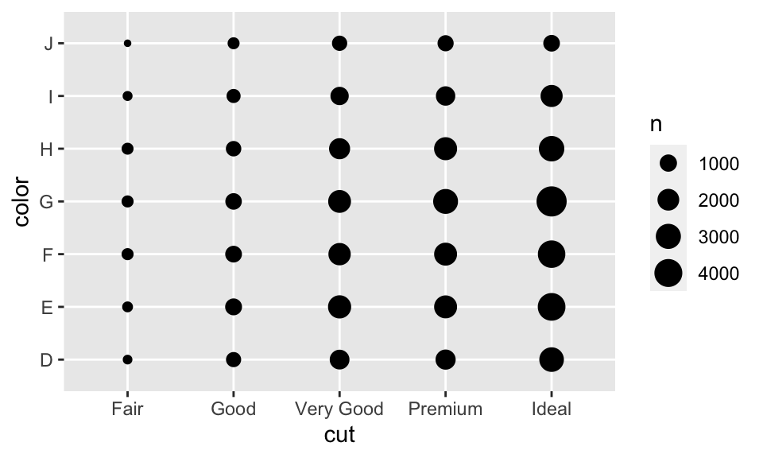

```r
ggplot(data = diamonds, aes(x = cut, y = color)) +
  geom_count() #<<
```

***

# Covariación: Categórica - Categórica

# ¿Cómo harías esto con `dplyr`?

```r
diamonds %>%
  group_by(color, cut) %>%
  summarise(n = n())
```

```
## # A tibble: 35 × 3
## # Groups:   color [7]
##    color cut           n
##    <ord> <ord>     <int>
##  1 D     Fair        163
##  2 D     Good        662
##  3 D     Very Good  1513
##  4 D     Premium    1603
##  5 D     Ideal      2834
##  6 E     Fair        224
##  7 E     Good        933
##  8 E     Very Good  2400
##  9 E     Premium    2337
## 10 E     Ideal      3903
## # … with 25 more rows
```

# Covariación: Categórica - Categórica

También sirve

```r
diamonds %>%
  count(color, cut)
```

```
## # A tibble: 35 × 3
##    color cut           n
##    <ord> <ord>     <int>
##  1 D     Fair        163
##  2 D     Good        662
##  3 D     Very Good  1513
##  4 D     Premium    1603
##  5 D     Ideal      2834
##  6 E     Fair        224
##  7 E     Good        933
##  8 E     Very Good  2400
##  9 E     Premium    2337
## 10 E     Ideal      3903
## # … with 25 more rows
```

# Covariación: Categórica - Categórica

Con esto

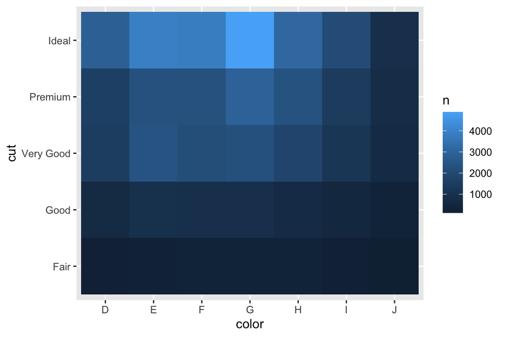

```r
diamonds %>%
  count(color, cut) %>%
  ggplot(aes(x = color, y = cut, fill = n))+
  geom_tile() #<<
```

# Covariación: Contínua - Contínua

- Vimos cómo hacerlo con `geom_point()`
- En datasets muy grandes, puntos solapan
- ¿Idea? Usar `aplha`

# Covariación: Contínua - Contínua

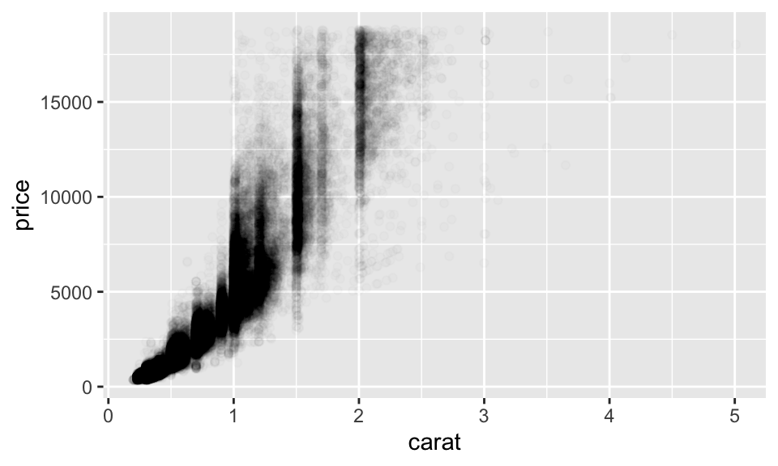

```r
ggplot(data=diamonds, aes(x = carat, y = price)) +
  geom_point(alpha = 0.01) #<<
```

# Covariación: Contínua - Contínua

Mejor

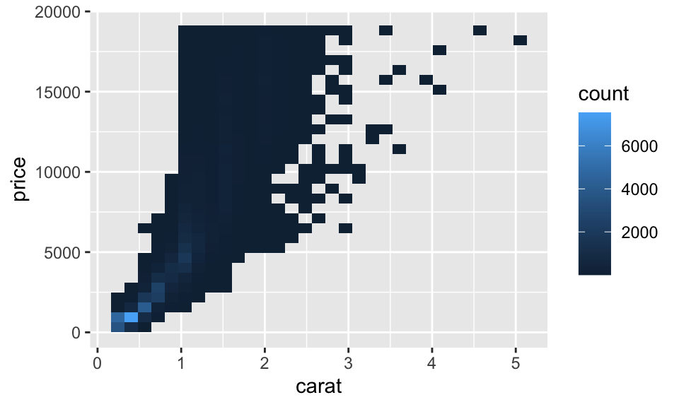

```r
ggplot(data=diamonds, aes(x = carat, y = price)) +
  geom_bin2d() #<<
```

# Covariación: Contínua - Contínua

Mejor

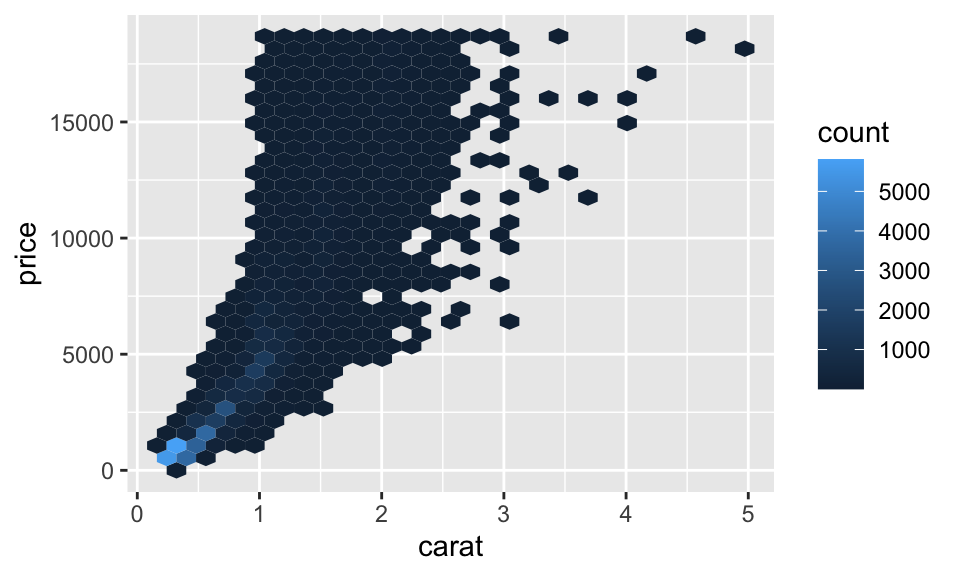

```r
# install.packages("hexbin")
ggplot(data=diamonds, aes(x = carat, y = price)) +
  geom_hex() #<<
```

# Covariación: Contínua - Contínua

Otra opción

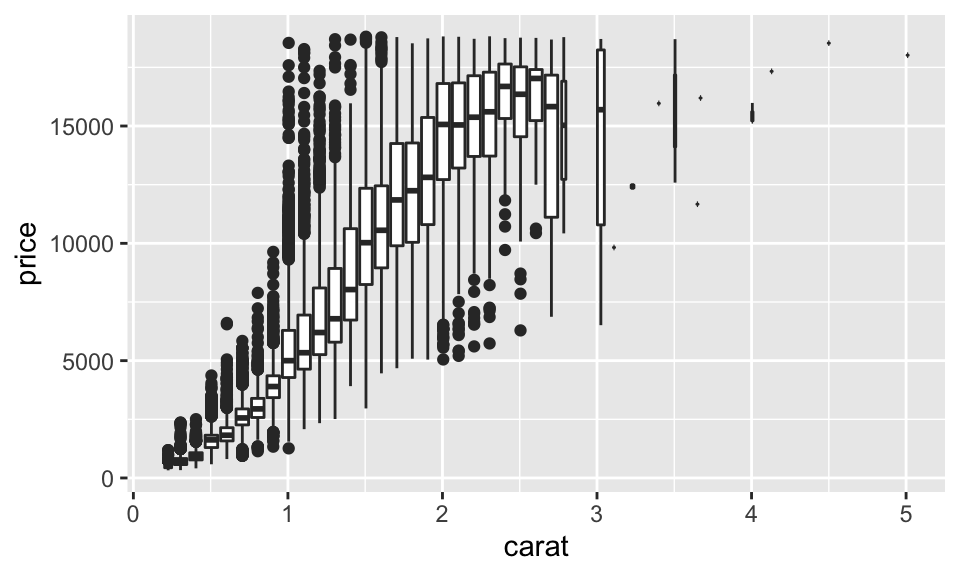

```r
ggplot(data=diamonds, aes(x = carat, y = price, )) +
  geom_boxplot(aes(group = cut_width(carat, 0.1)) ) #<<
```

# Covariación: Contínua - Contínua

Otra opción (mismo número de puntos por cada bin)

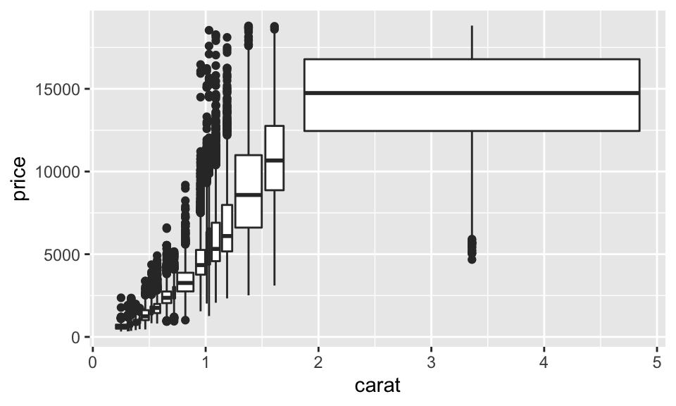

```r
ggplot(data=diamonds, aes(x = carat, y = price, )) +
  geom_boxplot(aes(group = cut_number(carat, 20)) ) #<<
```

# EDA: Patrones y modelos

# Patrones y modelos

Los patrones revelan pistas acerca de relaciones entre variables. Ante uno, cabe preguntarse

- ¿Puede ser debido al azar?
- ¿Cómo se describe la relación que implica?
- ¿Cómo es de fuerte?
- ¿Qué otras variables afectan esta relación?
- ¿Cambian la relación si observamos subgrupos de los datos?

Los **modelos** sirven para extraer patrones de los datos…

… e.g. pueden usarse para eliminar el efecto de una variable y estudiar el efecto restante.

# Bibliografía

- [R for Data Science](https://r4ds.had.co.nz/), Wickham and Grolemund (2016)